# Time Series Homework: Chapter 4 Lesson 4

Tristan Farrow

Revision: I corrected my data collection and the polyroot codes.

## Data

```r
exuseu <- rio::import("https://byuistats.github.io/timeseries/data/exuseu.csv")
```

## Questions

### Question 1 - Context and Measurement (5 points)

The first part of any time series analysis is context. You cannot properly analyze data without knowing what the data is measuring. Without context, the most simple features of data can be obscure and inscrutable. This homework assignment will center around the series below.

Please research the time series. In the spaces below, give the data collection process, unit of analysis, and meaning of each observation for the series.

#### a) Dollar-Euro Exchange Rate

[FRED](https://fred.stlouisfed.org/series/DEXUSEU)

**NoteAnswer**

Data Collection Process:

The data is a daily collection of the foreign exchange rate if one U.S. dollar to Euro for business days.

Units of Analysis:

Meaning of Observation:

Each observation represents U.S. Dollars to One Euro at a specific point in time. In other words, each value tells you how many U.S. dollars are needed to purchase one euro at the spot exchange rate (the current market rate for immediate currency exchange).

### Question 2 - Sneaky AR(2) (50 points)

#### a) Simulate an AR(2) process with $n=100, \mu=0,\alpha_1=0.25, \alpha_2=0.1, \sigma^2=1$

**NoteAnswer**

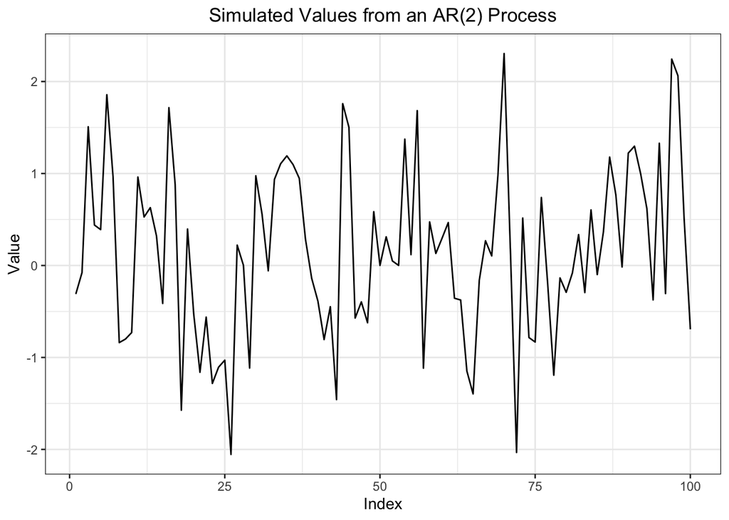

```r
set.seed(123)
n_rep <- 100
alpha0 <- 0
alpha1 <- 0.25
alpha2 <- 0.1
sigma_sqr <- 1

data_ts <- tibble(w = rnorm(n = n_rep, sd = sqrt(sigma_sqr))) %>%
  mutate(
    index = 1:n(),
    x = 0
  ) %>%
  tsibble::as_tsibble(index = index)

data_ts$x[1] <- alpha1 + data_ts$w[1]
data_ts$x[2] <- alpha0 + alpha1 * (data_ts$x[1] - alpha0) + data_ts$x[2]
for (i in 3:nrow(data_ts)){
  data_ts$x[i] <- alpha0 + alpha1 * (data_ts$x[i-1] - alpha0) +
    alpha2 * (data_ts$x[i-2] - alpha0) + data_ts$w[i]
}

data_ts %>%
  autoplot(.vars = x) +
  labs(
    title = "Simulated Values from an AR(2) Process",
    x = "Index",
    y = "Value"
  ) +
  theme_bw() +
  theme(plot.title = element_text(hjust = 0.5))
```

#### b) Is the AR(2) process stationary? Please use the characteristic equation method and report your results in a table.

**NoteAnswer**

```r
polyroot(c(1, -0.25, -0.1)) %>% abs() %>% round(3)
```

```
[1] 2.15 4.65
```

$$x_{t} = 0.25_{x_{t-1}} + 0.1_{x{t-2}} + w_{t}$$

$$\theta p(B) = -0.25(B)-0.1(B^2)+1$$

All of the roots return larger than 1 and so it can be concluded that the model is stationary.

#### c) Let R decide how many lags between 1 and 9 to fit the simulated series. Try it a few times. How often were the model parameters inside the estimate’s confidence intervals?

**NoteAnswer**

```r
model_fit <- data_ts %>%
  model(AR(x ~ order(1:9)))

ci_summary <- tidy(model_fit) %>%
  mutate(
    lower = estimate - 2 * std.error,
    upper = estimate + 2 * std.error
  )

pander(ci_summary)
```

Table continues below

| .model | term | estimate | std.error | statistic | p.value |
| --- | --- | --- | --- | --- | --- |
| AR(x ~ order(1:9)) | ar1 | 0.2635 | 0.09718 | 2.712 | 0.007889 |

| lower | upper |
| --- | --- |
| 0.06918 | 0.4579 |

R chose to use a AR(1) model for the data and the estimate for it was rather close. The confidence interval for the estimate is very large ranging from 0.07 - 0.458. This shows that the model does not have high confidence in it’s estimate.

#### d) Increase n to 1000. Repeat part c. Did the R routine obtain better estimates?

**NoteAnswer**

```r
set.seed(123)
n_rep <- 1000
alpha0 <- 0
alpha1 <- 0.25
alpha2 <- 0.1
sigma_sqr <- 1

data_ts2<- tibble(w = rnorm(n = n_rep, sd = sqrt(sigma_sqr))) %>%
  mutate(
    index = 1:n(),
    x = 0
  ) %>%
  tsibble::as_tsibble(index = index)

data_ts2$x[1] <- alpha1 + data_ts2$w[1]
data_ts2$x[2] <- alpha0 + alpha1 * (data_ts2$x[1] - alpha0) + data_ts2$x[2]
for (i in 3:nrow(data_ts2)){
  data_ts2$x[i] <- alpha0 + alpha1 * (data_ts2$x[i-1] - alpha0) +
    alpha2 * (data_ts2$x[i-2] - alpha0) + data_ts2$w[i]
}


model_fit2 <- data_ts2 %>%
  model(AR(x ~ order(1:9)))

ci_summary2 <- tidy(model_fit2) %>%
  mutate(
    lower = estimate - 2 * std.error,
    upper = estimate + 2 * std.error
  )

pander(ci_summary2)
```

Table continues below

| .model | term | estimate | std.error | statistic | p.value |
| --- | --- | --- | --- | --- | --- |
| AR(x ~ order(1:9)) | ar1 | 0.2196 | 0.03157 | 6.956 | 6.313e-12 |
| AR(x ~ order(1:9)) | ar2 | 0.07362 | 0.03158 | 2.331 | 0.01993 |

| lower | upper |
| --- | --- |
| 0.1565 | 0.2828 |
| 0.01046 | 0.1368 |

The estimates were much closer and the confidence interval range contained the true parameters.

#### e) How much trust should you have in R’s model fitting routine when you don’t know what the data generating process is?

**NoteAnswer**

You should put very little trust in R’s fitting routine. Without the context of the data it is hard to tell how accurate it is in choosing the model. Using tools like AIC, pacf, and general practice can help in choosing more accurate models.

### Question 3 - Stationarity and AR(p) fitting (50 points)

A key assumption when fitting AR(p)) models is that the time series data is stationary. Stationarity ensures that the statistical properties of the series remain constant over time, so our estimates of the mean, variance, and temporal relationships are valid. Non-stationary data, characterized by trends or changing mean and variance, can lead to unreliable parameter estimates and inaccurate forecasts when using AR(p) models. To address non-stationarity, a common solution is to apply differencing, particularly first differencing. By employing first differencing, the non-stationary series can be transformed into a stationary form, allowing for the application of AR(p) models with more confidence and accuracy.

#### a) Plot the Dollar-Euro Exchange Rate series, it’s correlogram, and a partial correlogram. Is the series stationary?

**NoteAnswer**

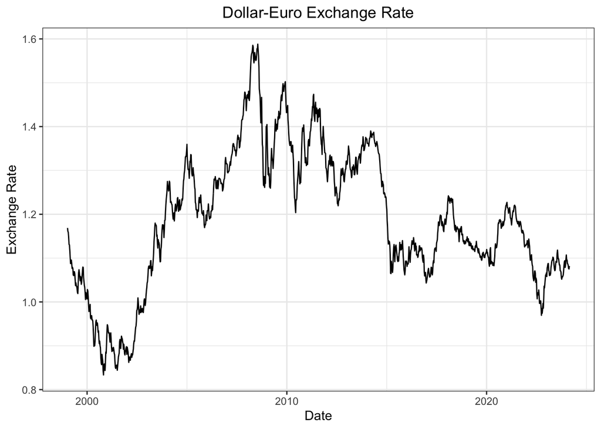

```r
exuseu_ts <- exuseu %>%
  mutate(
    date2 = mdy(date)
  ) %>%
  select(date2, exuseu) %>%
  tsibble(index = date2)

ggplot(
  data = exuseu_ts,
  aes(x = date2, y =exuseu)
) +
  geom_line() +
  labs(
    title = "Dollar-Euro Exchange Rate",
    x = "Date",
    y = "Exchange Rate"
  ) +
  theme_bw() +
  theme(plot.title = element_text(hjust = 0.5))
```

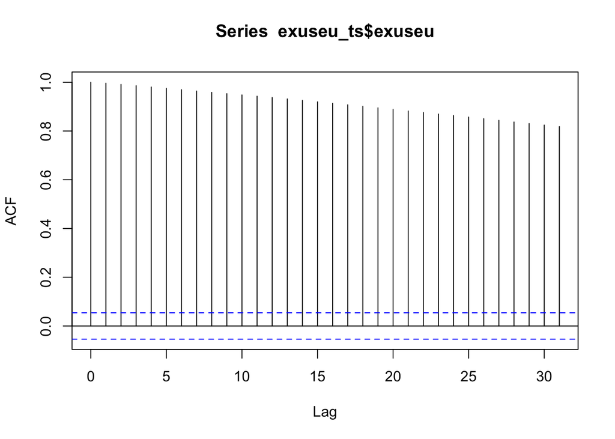

```r
acf(exuseu_ts$exuseu, plot=TRUE, type = "correlation")
```

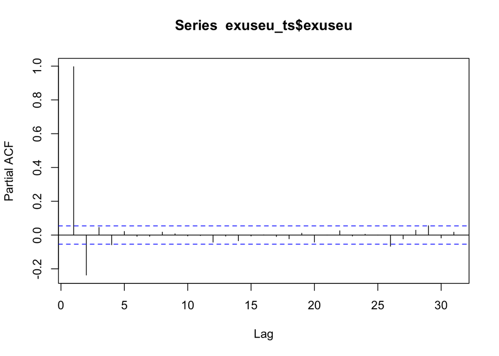

```r
pacf(exuseu_ts$exuseu)
```

The acf has a slow decay over time that can be an indication of a non-stationary series like a random walk. It most likely needs differencing to become stationary.

#### b) Fit an AR(p) model to the data by letting R choose how many lags to use? Please report your results in a table.

**NoteAnswer**

```r
exch_ar <- exuseu_ts %>%
  model(AR(exuseu))

pander(exch_ar)
```

| AR(exuseu) |
| --- |
| <AR(4) w/ mean> |

```r
tidy(exch_ar)
```

```
# A tibble: 5 × 6
  .model     term     estimate std.error statistic   p.value
  <chr>      <chr>       <dbl>     <dbl>     <dbl>     <dbl>
1 AR(exuseu) constant  0.00480   0.00261      1.84 6.64e-  2
2 AR(exuseu) ar1       1.26      0.0276      45.5  4.54e-272
3 AR(exuseu) ar2      -0.326     0.0442      -7.37 2.94e- 13
4 AR(exuseu) ar3       0.129     0.0442       2.93 3.48e-  3
5 AR(exuseu) ar4      -0.0640    0.0276      -2.32 2.05e-  2
```

#### c) Is the fitted model stationary? Would you use the fitted model as the basis for forecasting?

**NoteAnswer**

```r
polyroot(c(1, -1.256, 0.326, -0.129, 0.064)) %>% abs() %>% round(3)
```

```
[1] 1.007 2.624 2.624 2.254
```

#### d) Take the first-difference of the Dollar-Euro Exchange Rate series.

**NoteAnswer**

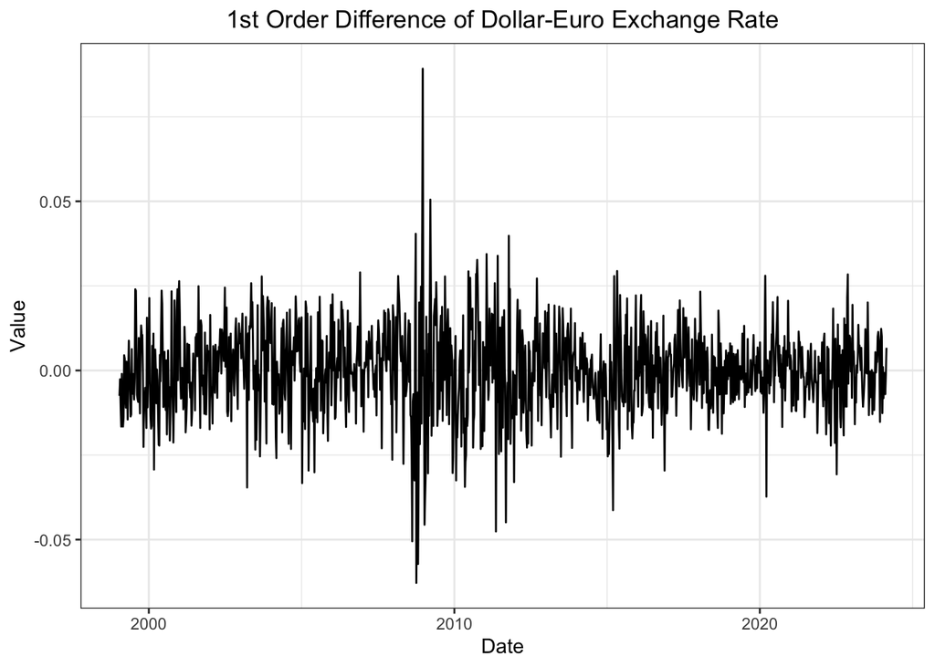

```r
exuseu_ts <- exuseu_ts %>%
  mutate(
    x_diff = exuseu - lag(exuseu)
  )

ggplot(
  data = exuseu_ts,
  aes(x = date2, y = x_diff)
) +
  geom_line() +
  labs(
    title = "1st Order Difference of Dollar-Euro Exchange Rate",
    x = "Date",
    y = "Value"
  ) +
  theme_bw() +
  theme(
    plot.title = element_text(hjust = 0.5)
  )
```

#### e) Plot the differenced series, it’s correlogram, and a partial correlogram. Is the series stationary?

**NoteAnswer**

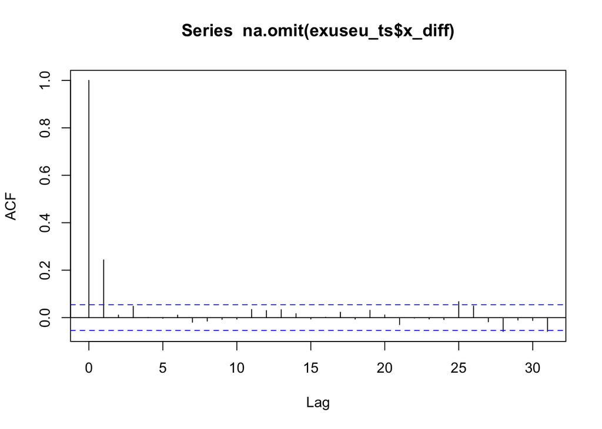

```r
acf(na.omit(exuseu_ts$x_diff), plot = TRUE, type = "correlation")
```

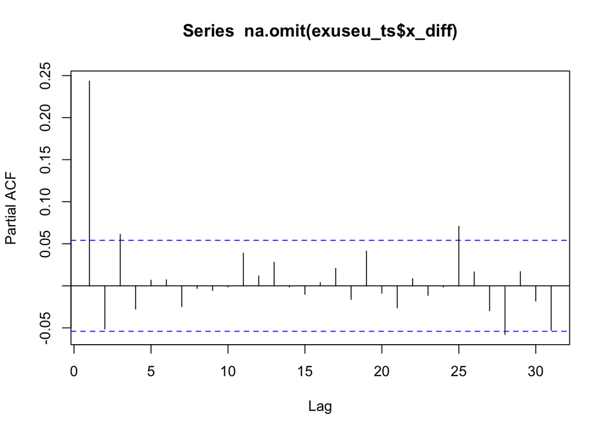

```r
pacf(na.omit(exuseu_ts$x_diff))
```

#### f) Fit an AR(p) model to the data by letting R choose how many lags to use? Please report your results in a table.

**NoteAnswer**

```r
exch_ar2 <- exuseu_ts %>%
  filter(!is.na(x_diff)) %>%
  model(AR(x_diff))

tidy(exch_ar2)
```

```
# A tibble: 3 × 6
  .model     term  estimate std.error statistic  p.value
  <chr>      <chr>    <dbl>     <dbl>     <dbl>    <dbl>
1 AR(x_diff) ar1     0.259     0.0276      9.39 2.61e-20
2 AR(x_diff) ar2    -0.0675    0.0284     -2.37 1.78e- 2
3 AR(x_diff) ar3     0.0614    0.0276      2.23 2.62e- 2
```

#### g) Is the fitted model stationary? Would you use the fitted model as the basis for forecasting?

**NoteAnswer**

```r
polyroot(c(1,-0.259, 0.067, -0.061)) %>% abs() %>% round(3)
```

```
[1] 2.318 2.659 2.659
```

The roots are greater than 1 and so the series is stationary and can be used to forecast. Now that the series follows the basic assumptions of the model, it will be more accurate in making predictions.

### Rubric

[output not shown]